# User and Usage Patterns in Ford GoBike For 2018's Users

## By (Mostafa Badran)

## Investigation Overview

> The Goal Of this Investigation was to do user's research and servies's usage pattern so the markting and opration team can improve the user experance and lead improve the servies Growth

## (Distribution of usage during 2018's months )

> it's show that the most of Summer's months is busy but also october was the most busy

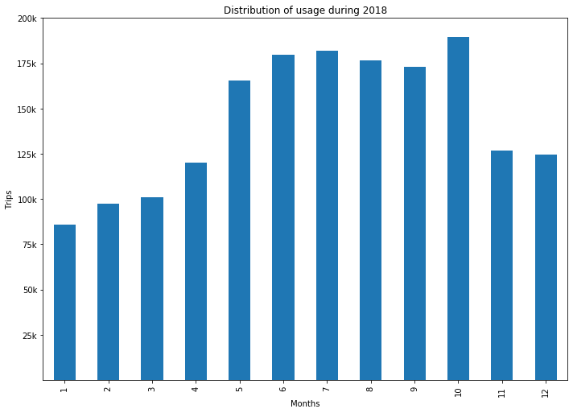

```python
plt.figure(figsize=[ 11.69, 8.27])

num_uses_per_month =df['start_time'].groupby(df.start_time.dt.month).agg('count')
num_uses_per_month
num_uses_per_month.plot(kind='bar');
plt.xlabel('Months');
plt.ylabel('Trips');
plt.title('Distribution of usage during 2018');
plt.yticks([25000,50000,75000,100000,125000,150000,175000,200000], ['25k', '50k', '75k', '100k', '125k', '150k','175k','200k']);
```

## (Age categories of users whom use the servies )

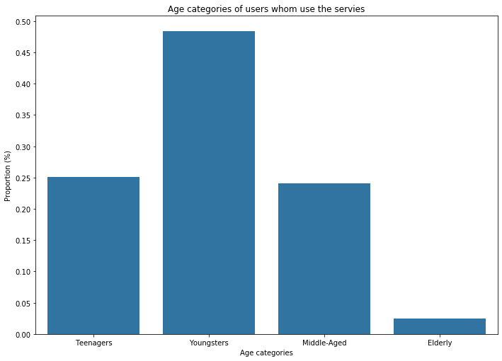

```python
plt.figure(figsize=[ 11.69, 8.27])


# making a new catacorial age columne
bin_edge=[16,28,40,60,85]
bin_names=["Teenagers","Youngsters","Middle-Aged", "Elderly"]
df2['catagoial_age']=pd.cut(df2['member_birth_year'],bin_edge,labels=bin_names)

# get proportion taken by most common group for derivation
# of tick marks
n_points = df2.shape[0]
max_count = df2['catagoial_age'].value_counts().max()
max_prop = max_count / n_points

# generate tick mark locations and names
tick_props = np.arange(0, max_prop+.05, 0.05)
tick_names = ['{:0.2f}'.format(v) for v in tick_props]

# create the plot
base_color = sb.color_palette()[0]
sb.countplot(data = df2, x = 'catagoial_age', color = base_color);
plt.yticks(tick_props * n_points, tick_names);
plt.ylabel('Proportion (%)');
plt.xlabel('Age categories');
plt.title('Age categories of users whom use the servies');
```

## ( Relation between the average user's age in every month )

> As Visualization shows that Average user age have decresing trend and that might illastreat that the servies start to get more popular between the younger than average so I recomend to to start awarnes campaign within younger as the represent a huge markert share with our servies

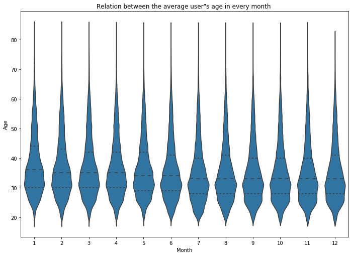

```python
plt.figure(figsize=[ 11.69, 8.27])

base_color = sb.color_palette()[0]
sb.violinplot(data = df2,x ='month', y ='member_birth_year',inner='quartile',color=base_color);
plt.ylabel('Age');
plt.xlabel('Month');
plt.title('Relation between the average user"s age in every month ');
```

## ( Gender and User type relation )

> As Visualization shows that the subscribers percentage on average ranges between (85~89%) dispite the gender and the diffrance between the gender isn't significant

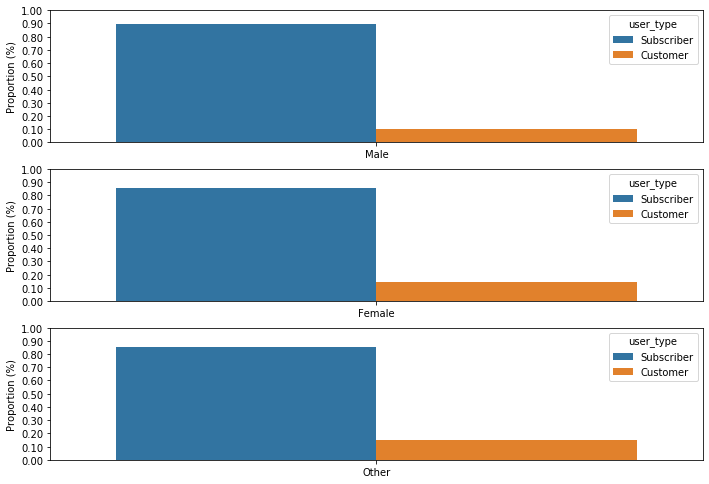

```python
#Men
plt.figure(figsize=[ 11.69, 8.27])
plt.subplot(3, 1, 1)
n_points = total_men.shape[0]
max_count = total_men['member_gender'].value_counts().max()
max_prop = max_count / n_points
tick_props = np.arange(0, max_prop+.1, 0.1)
tick_names = ['{:0.2f}'.format(v) for v in tick_props]
sb.countplot(data= total_men,x='member_gender',hue='user_type');
plt.yticks(tick_props * n_points, tick_names);
plt.ylabel('Proportion (%)');
plt.xlabel("")

#Woman
plt.subplot(3, 1, 2)
n_points = total_women.shape[0]
max_count = total_women['member_gender'].value_counts().max()
max_prop = max_count / n_points
tick_props = np.arange(0, max_prop+.1, 0.1)
tick_names = ['{:0.2f}'.format(v) for v in tick_props]
sb.countplot(data= total_women,x='member_gender',hue='user_type');
plt.yticks(tick_props * n_points, tick_names);
plt.ylabel('Proportion (%)');
plt.xlabel("")
#Other
plt.subplot(3, 1, 3)
n_points = total_other.shape[0]
max_count = total_other['member_gender'].value_counts().max()
max_prop = max_count / n_points
tick_props = np.arange(0, max_prop+.1, 0.1)
tick_names = ['{:0.2f}'.format(v) for v in tick_props]
sb.countplot(data= total_other,x='member_gender',hue='user_type');
plt.yticks(tick_props * n_points, tick_names);
plt.ylabel('Proportion (%)');
plt.xlabel("");
```

## Releationship between Member gender,Duration (min) and Membership Type

> Here it show that the average Ride Duration(min) to male/subscriber is nearly 10min and male/customer is nerly 18min

> Here it show that the average Ride Duration(min) to Other/subscriber is nearly 11min and male/customer is nerly 17min

> and here it show that the average ride for female user is longest than the other  
> and also show that the duration average nerly double in case of customer membership despite the Gender

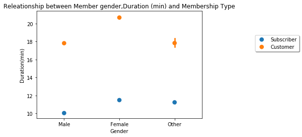

```python
ax = sb.pointplot(data = less120min, x = 'member_gender', y = 'duration_min', hue = 'user_type', linestyles = "");
plt.legend(loc='upper center', bbox_to_anchor=(1.45, 0.8), shadow=True, ncol=1);
plt.ylabel('Duration(min)');
plt.xlabel('Gender');
plt.title('Releationship between Member gender,Duration (min) and Membership Type');
```

# Releation ship between Member gender,Member age and Membership Type

> Here it show that the average age to female/subscriber is nearly 35 year and female/customer is nerly 32 year

> Here it show that the average age to Other/subscriber is nearly 37 year and male/customer is nerly 35 year

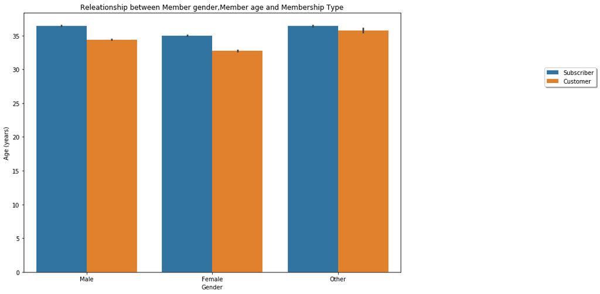

```python
plt.figure(figsize=[ 11.69, 8.27])

sb.barplot(data = df2, x = 'member_gender', y = 'member_birth_year', hue = 'user_type');
plt.legend(loc='upper center', bbox_to_anchor=(1.45, 0.8), shadow=True, ncol=1);
plt.title('Releationship between Member gender,Member age and Membership Type');
plt.ylabel('Age (years)');
plt.xlabel('Gender');
```